# A Statistical Analysis on Low birthweight and its Factors

2026-03-09

Upload the following library and packages before running the code below:

```r
library(MASS)
data(birthwt)
library(dplyr)
```

```r
library(ggplot2)
library(knitr)
library(effects)
```

##Abstract: The aim of this project is to explore significant relationships between low birthweight and predictors from the birthwt dataset in R. logistic regression was used to assess relationships between low birth weight and maternal characteristics, including alternative interpretations of physician visits. Model selection based on AIC identified maternal weight, race, smoking status, hypertension, previous premature labor, and uterine irritability as important predictors of low birth weight. Physician visits were not retained in the final model as they did not improve the model fit.

##Data description: The dataset is uploaded from the MASS library and renamed as birthData. The following variables that are split into 10 columns are as follows:

● low: indicator (1 for low birthweight and 0 for non-low birthweight) of birth weight less than 2.5kg, ● age: mother’s age in years, ● lwt: mother’s weight in pounds at last menstrual period, ● race: mother’s race (1 = white, 2 = black, 3 = other), ● smoke: smoking status during pregnancy, ● ptl: number of previous premature labours, ● ht: history of hypertension, ● ui: presence of uterine irritability, ● ftv: number of physician visits during the first trimester, ● bwt: birth weight in grams.

The following plots are produced:

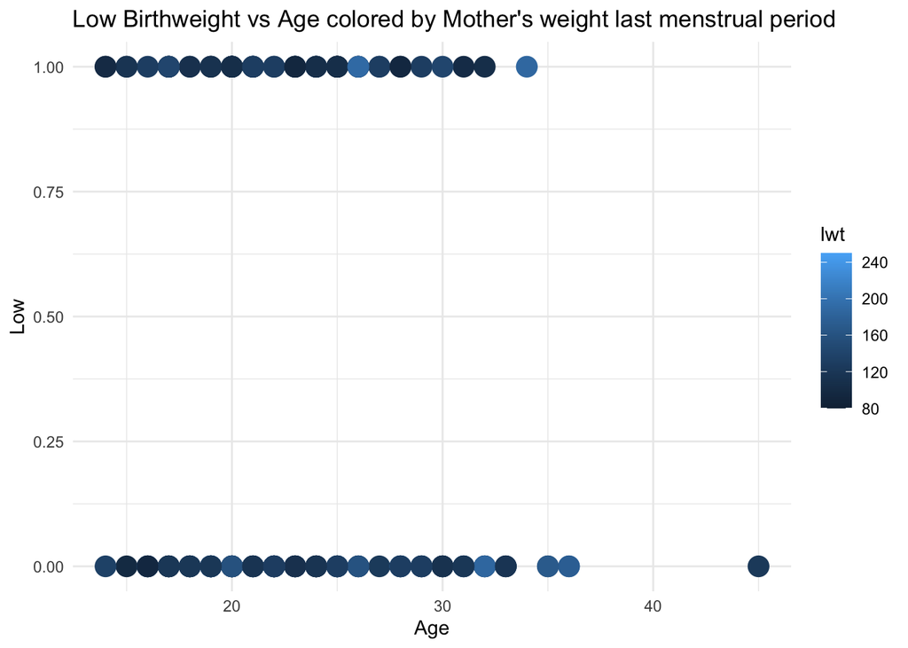

```r
# Create the plot continuous x variable : age, lwt vs low
ggplot(birthData, aes(x = age, y = low, color = lwt)) +
  geom_point(size=5) +
  labs(title = "Low Birthweight vs Age colored by Mother's weight last menstrual period",
       x = "Age",
       y = "Low",
       color = "lwt") +
  theme_minimal()
```

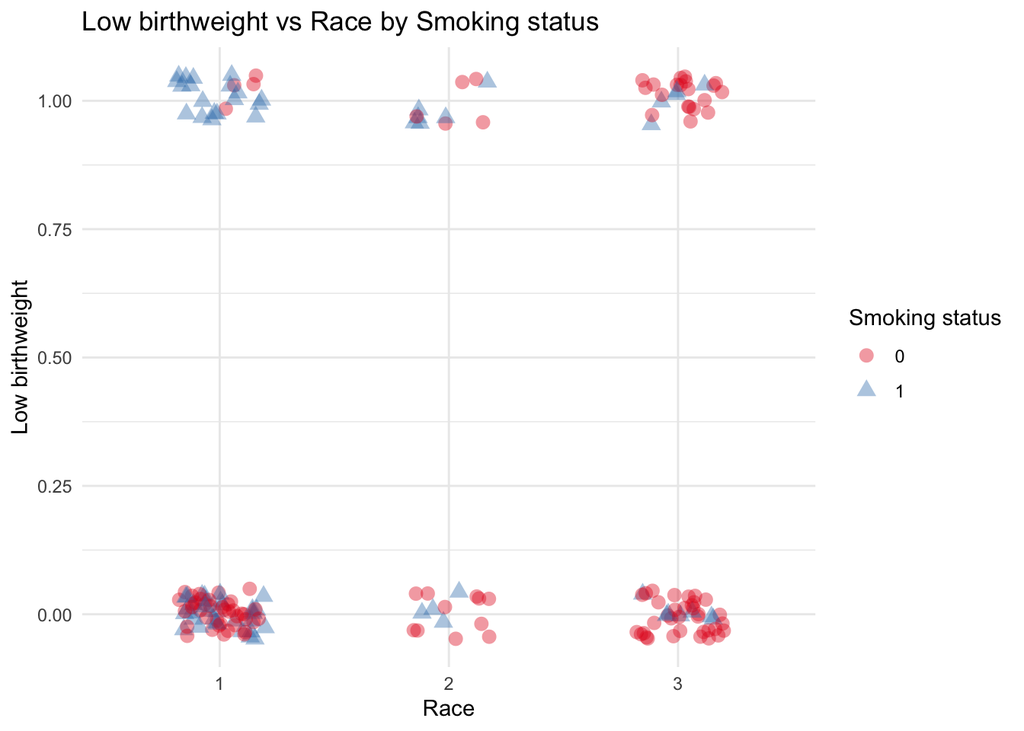

```r
raceFactor = as.factor(birthData$race) #race of mom
smokeFactor = as.factor(birthData$smoke) #smoker/non-smoker
htFactor = as.factor(birthData$ht) #has hypertension/ no hypertension
uiFactor = as.factor(birthData$ui) # uterine iritability/ no iritability
ftvFactor = as.factor(birthData$ftv) # physician visit / no visit

# Low vs. Race by Smoking status

ggplot(birthData, aes(x = raceFactor, y = low, color = smokeFactor, shape = smokeFactor)) +
  geom_jitter(size=3, alpha = 0.4, position = position_jitter(width=0.2, height = 0.05)) +
  scale_color_brewer(palette="Set1")+
  labs(title = "Low birthweight vs Race by Smoking status",
       x = "Race",
       y = "Low birthweight",
       color = "Smoking status",
       shape = "Smoking status") +
  theme_minimal()
```

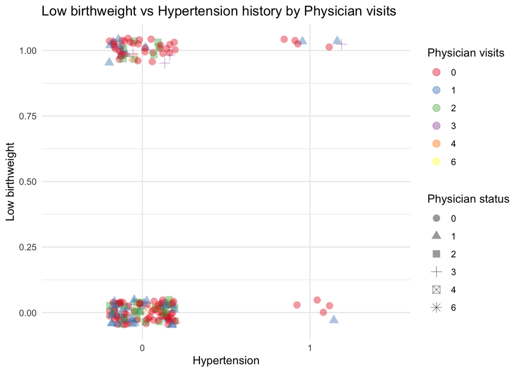

```r
# Low vs. hypertension by physician visit
ggplot(birthData, aes(x = htFactor, y = low, color = ftvFactor, shape = ftvFactor)) +
  geom_jitter(size=3, alpha = 0.4, position = position_jitter(width=0.2, height = 0.05)) +
  scale_color_brewer(palette="Set1") +
  labs(title = "Low birthweight vs Hypertension history by Physician visits",
       x = "Hypertension",
       y = "Low birthweight",
       color = "Physician visits",
       shape = "Physician status") +
  theme_minimal()
```

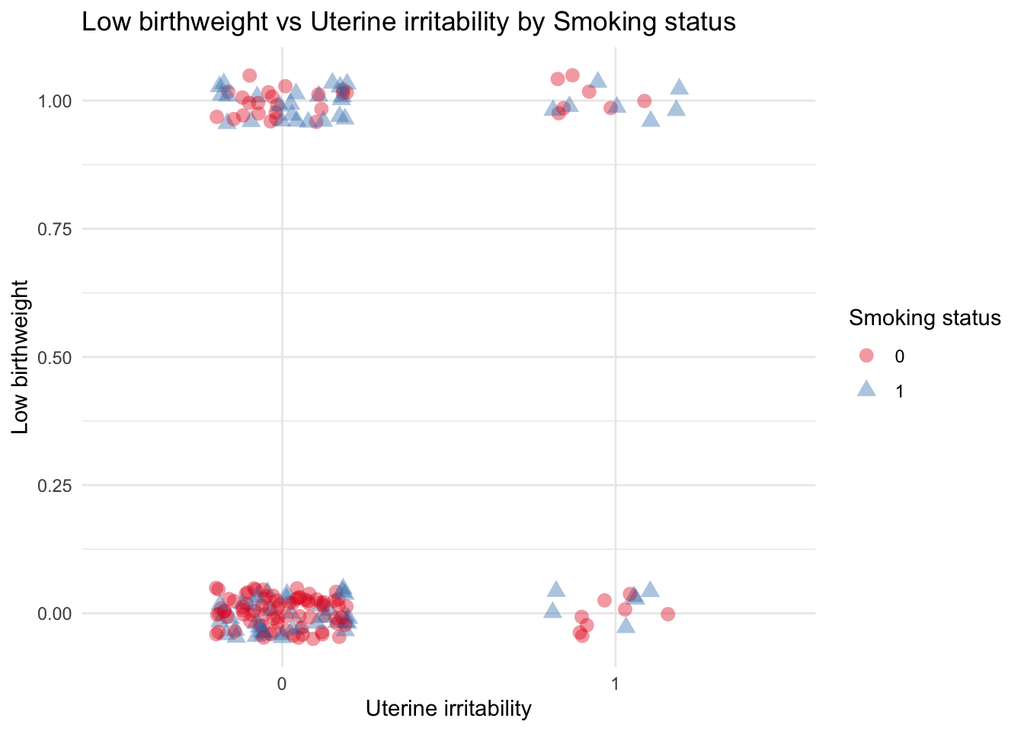

```r
# Low vs. uterine irritability by Smoking status
ggplot(birthData, aes(x = uiFactor, y = low, color = smokeFactor, shape = smokeFactor)) +
  geom_jitter(size=3, alpha = 0.4, position = position_jitter(width=0.2, height = 0.05)) +
  scale_color_brewer(palette="Set1") +
  labs(title = "Low birthweight vs Uterine irritability by Smoking status",
       x = "Uterine irritability",
       y = "Low birthweight",
       color = "Smoking status",
       shape = "Smoking status") +
  theme_minimal()
```

##Transformation of variables

Six of the independent variables in this dataset are categorical variables and therefore need transformation using the as.factor() function. Upon investigating the dataset, a table is produced with columns corresponding to the number of visits and rows as to how many mothers have had several physician visits. This variable is re-coded into two ways for simplified analysis: a) Creating two categories of physician visits wherein women who had no physician visits as ‘none’ and ‘some’ for those with one or more visits b) Creating three categories wherein ‘none’ corresponds to zero visits, ‘1’ is to one visit, and ‘some’ is to two or many.

```r
birthData$ftv.recoded = factor(recode(birthData$ftv, '0'="0", '1'="1", .default="2+"))
birthData$ftv.recoded2 = factor(recode(birthData$ftv, '0'="none", .default="some"))
```

Compare ftv and ftv.recoded

```r
xtabs(~ftv + ftv.recoded2, data = birthData)
```

```
##    ftv.recoded2
## ftv none some
##   0  100    0
##   1    0   47
##   2    0   30
##   3    0    7
##   4    0    4
##   6    0    1
```

```r
xtabs(~ftv + ftv.recoded, data = birthData)
```

```
##    ftv.recoded
## ftv   0   1  2+
##   0 100   0   0
##   1   0  47   0
##   2   0   0  30
##   3   0   0   7
##   4   0   0   4
##   6   0   0   1
```

From ftv.recoded 2, there are 100 patients who had no visits to the physician while a number of then had more than 1 visits which are labelled under ‘some’. On the other hand, ftv.recoded shares the same idea but instead of ‘some’, it is generalised into patients who had 2 or more visits (i.e, 7 patients with 3 visits).

##Methodology: The conceptual model of predicting low birth weight is formulated below:

```r
birthGLM<- glm(low ~ age + lwt + raceFactor + smokeFactor + ptl + htFactor + uiFactor + ftv.recoded, data = birthData, family = binomial(link="logit"))
summary(birthGLM)
```

```
##
## Call:
## glm(formula = low ~ age + lwt + raceFactor + smokeFactor + ptl +
##     htFactor + uiFactor + ftv.recoded, family = binomial(link = "logit"),
##     data = birthData)
##
## Coefficients:
##                Estimate Std. Error z value Pr(>|z|)
## (Intercept)    0.590930   1.213568   0.487  0.62630
## age           -0.026945   0.037414  -0.720  0.47141
## lwt           -0.015748   0.006963  -2.262  0.02371 *
## raceFactor2    1.254016   0.529382   2.369  0.01784 *
## raceFactor3    0.820827   0.451042   1.820  0.06878 .
## smokeFactor1   0.865245   0.414450   2.088  0.03683 *
## ptl            0.604607   0.357445   1.691  0.09075 .
## htFactor1      1.894689   0.705977   2.684  0.00728 **
## uiFactor1      0.732822   0.460442   1.592  0.11148
## ftv.recoded1  -0.299057   0.463918  -0.645  0.51917
## ftv.recoded2+  0.178370   0.450777   0.396  0.69233
## ---
## Signif. codes:  0 '***' 0.001 '**' 0.01 '*' 0.05 '.' 0.1 ' ' 1
##
## (Dispersion parameter for binomial family taken to be 1)
##
##     Null deviance: 234.67  on 188  degrees of freedom
## Residual deviance: 200.61  on 178  degrees of freedom
## AIC: 222.61
##
## Number of Fisher Scoring iterations: 4
```

```r
cbind(
  Estimate = coef(birthGLM),
  OddsRatio = exp(coef(birthGLM))
)
```

```
##                  Estimate OddsRatio
## (Intercept)    0.59092990 1.8056667
## age           -0.02694506 0.9734147
## lwt           -0.01574795 0.9843754
## raceFactor2    1.25401614 3.5043888
## raceFactor3    0.82082713 2.2723786
## smokeFactor1   0.86524468 2.3755873
## ptl            0.60460666 1.8305320
## htFactor1      1.89468893 6.6504793
## uiFactor1      0.73282174 2.0809442
## ftv.recoded1  -0.29905683 0.7415173
## ftv.recoded2+  0.17837007 1.1952676
```

From the birthGLM() model, a summary table was obtained presenting the estimated coefficients for each predictor along with their corresponding estimate, standard error, z value, and p-value. Predictors denoted with (.) and (*) were prioritized for analysis namely maternal weight (lwt), race (raceFactor2 = black, raceFactor3 = other), smoking status (smokeFactor1), number of previous labors (ptl), and hypertension history (htFactor1).

The resulting factors from the recoded ftv variable exhibited relatively high p-values, indicating no statistically significant association with low birth weight. Age and mother’s weight in pounds are negatively correlated to low birthweight. However, since age has a larger p-value than 0.05, it is statistically insignificant. Mothers are identified to have 0.98 times lower odds of having a low birthweight of their babies. On the other hand, those who smoke have 2.38 higher odds of birthing low-weighted babies. Low birthweight prevalence shows a pronounced racial disparity, with findings indicating a 3.50 odds ratio among Black women compared to white women, whereas women categorized as other races faced 2.27 higher odds. Lastly, those with hypertension history have significantly higher odds, with a ratio of 6.65 odds in birthing low-weighted babies.

```r
birthGLM_2<- glm(low ~ age + lwt + raceFactor + smokeFactor + ptl + htFactor + uiFactor + ftv.recoded2, data = birthData, family = binomial(link="logit"))
summary(birthGLM_2)
```

```
##
## Call:
## glm(formula = low ~ age + lwt + raceFactor + smokeFactor + ptl +
##     htFactor + uiFactor + ftv.recoded2, family = binomial(link = "logit"),
##     data = birthData)
##
## Coefficients:
##                   Estimate Std. Error z value Pr(>|z|)
## (Intercept)       0.476013   1.208748   0.394  0.69372
## age              -0.025837   0.037268  -0.693  0.48814
## lwt              -0.015175   0.006933  -2.189  0.02862 *
## raceFactor2       1.257915   0.527641   2.384  0.01712 *
## raceFactor3       0.846474   0.449611   1.883  0.05974 .
## smokeFactor1      0.908886   0.411191   2.210  0.02708 *
## ptl               0.544725   0.347467   1.568  0.11695
## htFactor1         1.825933   0.693679   2.632  0.00848 **
## uiFactor1         0.754549   0.460416   1.639  0.10125
## ftv.recoded2some -0.059043   0.369227  -0.160  0.87295
## ---
## Signif. codes:  0 '***' 0.001 '**' 0.01 '*' 0.05 '.' 0.1 ' ' 1
##
## (Dispersion parameter for binomial family taken to be 1)
##
##     Null deviance: 234.67  on 188  degrees of freedom
## Residual deviance: 201.40  on 179  degrees of freedom
## AIC: 221.4
##
## Number of Fisher Scoring iterations: 4
```

```r
cbind(
  Estimate = coef(birthGLM_2),
  OddsRatio = exp(coef(birthGLM_2))
)
```

```
##                     Estimate OddsRatio
## (Intercept)       0.47601266 1.6096434
## age              -0.02583652 0.9744944
## lwt              -0.01517499 0.9849396
## raceFactor2       1.25791496 3.5180785
## raceFactor3       0.84647396 2.3314117
## smokeFactor1      0.90888564 2.4815557
## ptl               0.54472550 1.7241350
## htFactor1         1.82593320 6.2085861
## uiFactor1         0.75454900 2.1266522
## ftv.recoded2some -0.05904313 0.9426661
```

##Model Diagnostics

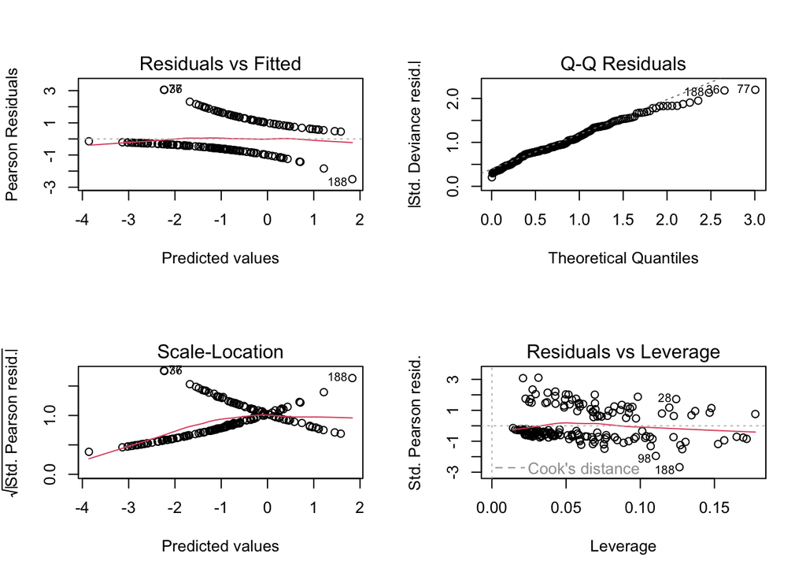

```r
# Generate standard diagnostic plots
par(mfrow = c(2, 2)) # Arrange plots in a 2x2 grid
plot(birthGLM)
```

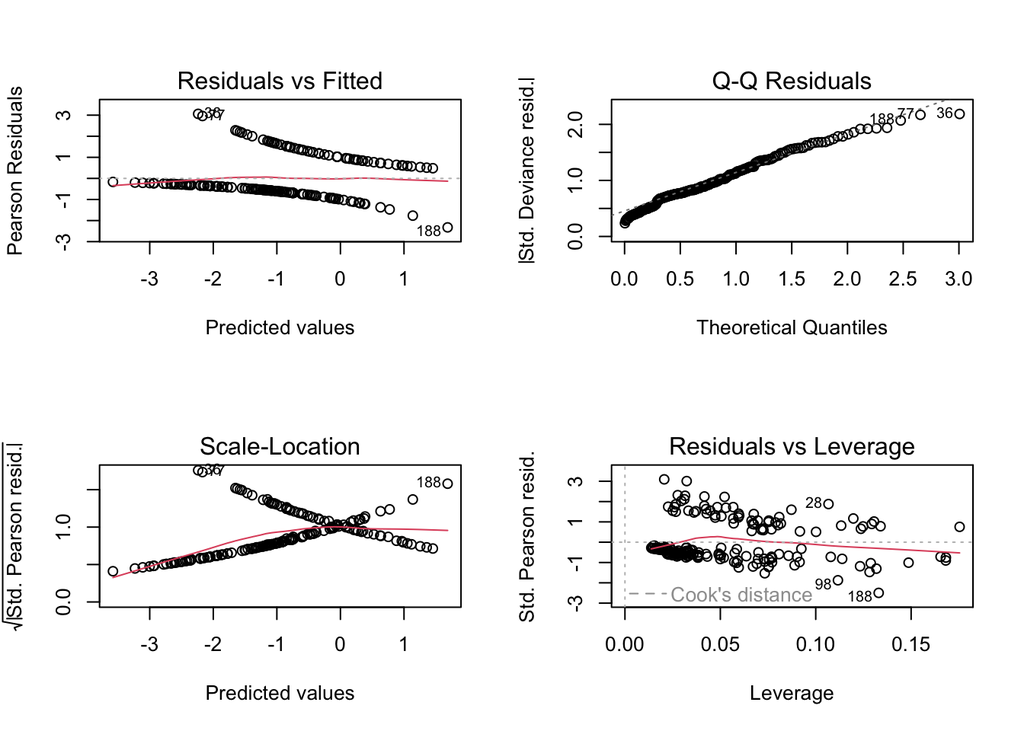

```r
plot(birthGLM_2)
```

```r
birthGLM_3 <- step(birthGLM_2, scope = list(lower = "~1", upper = "~( age + lwt + raceFactor + smokeFactor + ptl + htFactor + uiFactor + ftv.recoded2)"))
```

```
## Start:  AIC=221.4
## low ~ age + lwt + raceFactor + smokeFactor + ptl + htFactor +
##     uiFactor + ftv.recoded2
##
##                Df Deviance    AIC
## - ftv.recoded2  1   201.43 219.43
## - age           1   201.89 219.89
## <none>              201.40 221.40
## - ptl           1   203.94 221.94
## - uiFactor      1   204.04 222.04
## - smokeFactor   1   206.41 224.41
## - raceFactor    2   208.44 224.44
## - lwt           1   206.77 224.77
## - htFactor      1   208.67 226.67
##
## Step:  AIC=219.43
## low ~ age + lwt + raceFactor + smokeFactor + ptl + htFactor +
##     uiFactor
##
##                Df Deviance    AIC
## - age           1   201.99 217.99
## <none>              201.43 219.43
## - ptl           1   203.95 219.95
## - uiFactor      1   204.11 220.11
## + ftv.recoded2  1   201.40 221.40
## - raceFactor    2   208.77 222.77
## - lwt           1   206.81 222.81
## - smokeFactor   1   206.92 222.92
## - htFactor      1   208.81 224.81
##
## Step:  AIC=217.99
## low ~ lwt + raceFactor + smokeFactor + ptl + htFactor + uiFactor
##
##                Df Deviance    AIC
## <none>              201.99 217.99
## - ptl           1   204.22 218.22
## - uiFactor      1   204.90 218.90
## + age           1   201.43 219.43
## + ftv.recoded2  1   201.89 219.89
## - smokeFactor   1   207.73 221.73
## - lwt           1   208.11 222.11
## - raceFactor    2   210.31 222.31
## - htFactor      1   209.46 223.46
```

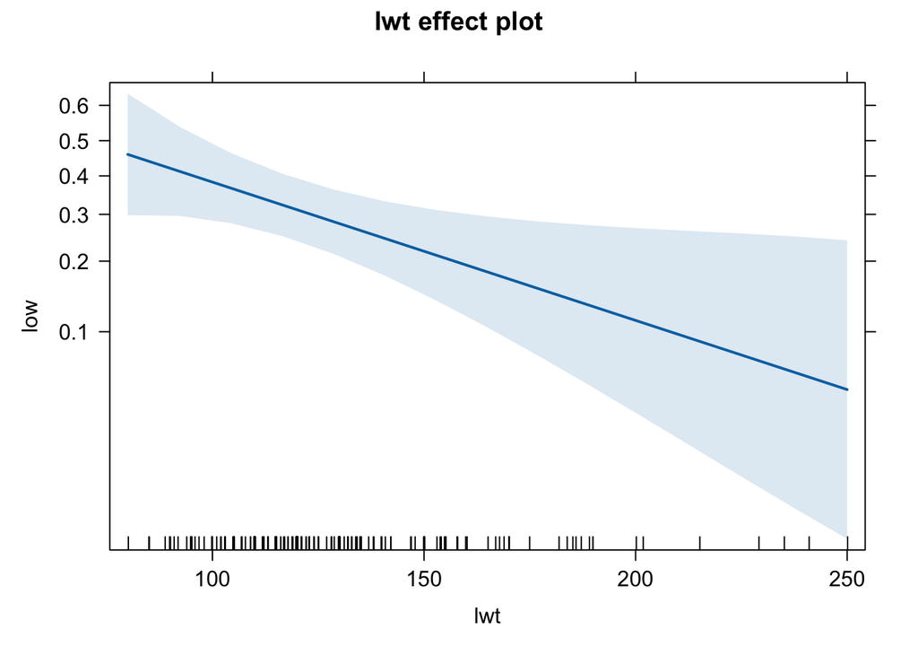

```r
birth.eff <- allEffects(birthGLM_3)
plot(birth.eff,selection = 1)
```

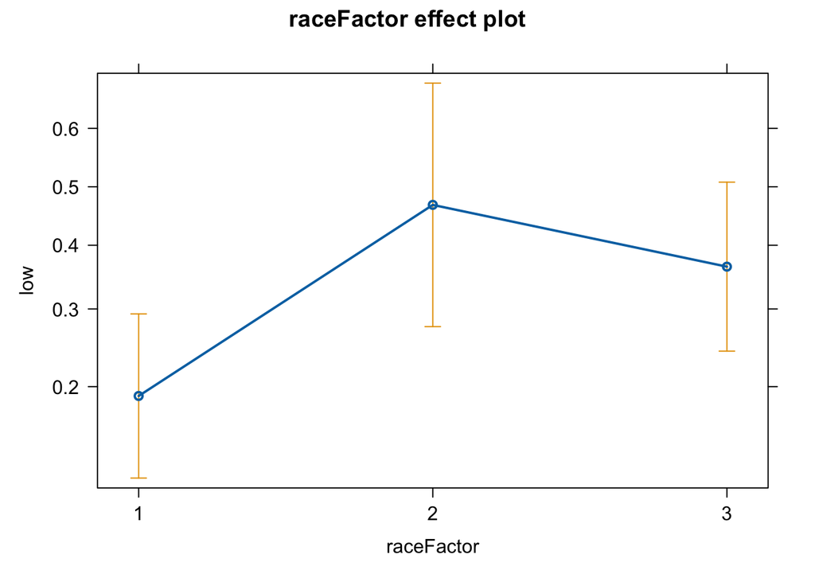

```r
plot(birth.eff,selection = 2)
```

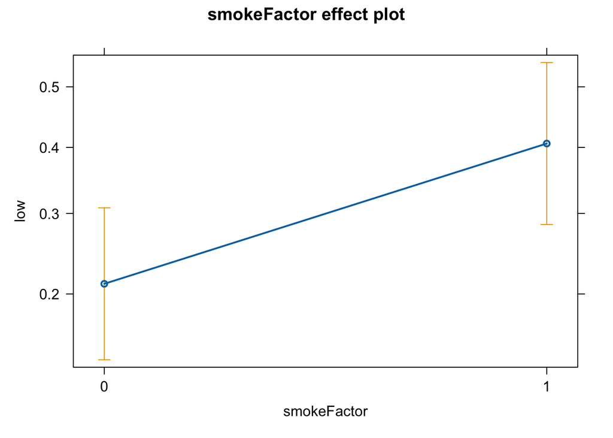

```r
plot(birth.eff,selection = 3)
```

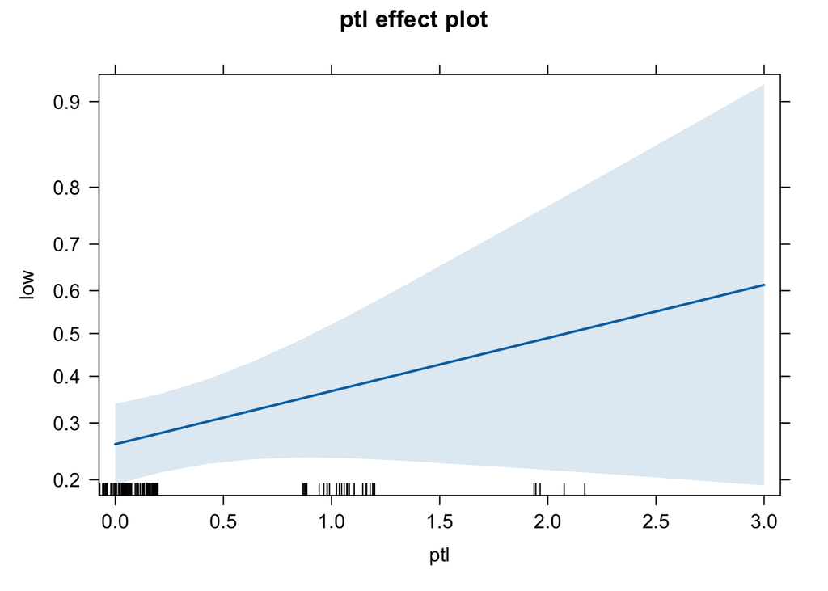

```r
plot(birth.eff,selection = 4, multiline = TRUE)
```

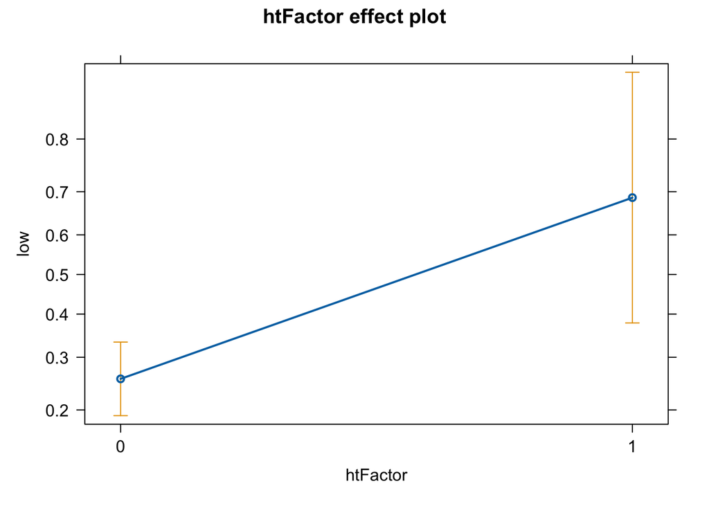

```r
plot(birth.eff,selection = 5, multiline = TRUE)
```

The stepwise model selection resulted to an AIC of 217.99 consisting the significant variables mother’s weight, race, smoking status, number of premature labors, hypertensions history, and presence of uterine irritability. Age and frequency of physician visits were excluded as it lacks explanatory power after adjustment of other covariates. A few potential reasons could be rooting from socioeconomic differences or mothers who are already facing high risk during pregnancy require frequent doctor’s attention.

##Conclusion In conclusion, six predictors were identified as independently associated with low birth weight. Maternal weight was negatively associated with low birth weight, indicating that higher maternal weight was linked to lower odds of low birth weight, while the remaining predictors were associated with increased odds. These predictors were selected through stepwise model selection using AIC. Frequency in physician visits was examined using different recoding strategies; however, it did not contribute additional explanatory power and was excluded from the final model. The final model that provided the best balance between model fit and complexity, included maternal weight, race, smoking status, number of previous labors, hypertension, and uterine irritability.